# How Peer Influence Affects Attribute Preferences: A Bayesian Updating Mechanism

Converted from PDF `Narayan-PeerInfluenceAttributePreferences-2011-MKSC.pdf` · 18 pages · anchors: page `#pN`, block `#pN-bK`

Page 1

[figure not shown]

NOTE: figure/graphic rendered as an image from the PDF; its content is not machine-readable text. Caption (if any) follows as the next block.

**text found inside the figure**

Marketing Science

Publication details, including instructions for authors and subscription information: http://pubsonline.informs.org

How Peer Influence Affects Attribute Preferences: A Bayesian Updating Mechanism

Vishal Narayan, Vithala R. Rao, Carolyne Saunders,

To cite this article: Vishal Narayan, Vithala R. Rao, Carolyne Saunders, (2011) How Peer Influence Affects Attribute Preferences: A Bayesian Updating Mechanism. Marketing Science 30(2):368-384. https://doi.org/10.1287/mksc.1100.0618

Full terms and conditions of use: https://pubsonline.informs.org/Publications/Librarians-Portal/PubsOnLine- Terms-and-Conditions

Copyright © 2011, INFORMS

Please scroll down for article—it is on subsequent pages

Page 2

CELEBRATING 30 YEARS Vol. 30, No. 2, March–April 2011, pp. 368–384 issn 0732-2399eissn 1526-548X1130020368

doi 10.1287/mksc.1100.0618

© 2011 INFORMS

## How Peer Influence Affects Attribute Preferences:

## A Bayesian Updating Mechanism

#### Vishal Narayan, Vithala R. Rao, Carolyne Saunders Johnson Graduate School of Management, Cornell University, Ithaca, New York 14853

e study how multiattribute product choices are affected by peer influence. We propose a two-stage conjoint-based approach to examine three behavioral mechanisms of peer influence. We find that when faced with information on peer choices, consumers update their attribute preferences in a Bayesian manner. This suggests that greater uncertainty in the attribute preferences of a focal consumer and lesser uncertainty in preferences of peers both lead to greater preference revision. Greater number of peers is associated with greater preference revision, although the extent of preference revision diminishes with increasing number of peers. Furthermore, to address the significant time and costs associated with collecting sociometric data, we estimate the accuracy of predicted consumer choices when peer influence data are unavailable. Online social network membership and frequency of peer interactions provide better proxies than more common demographic similarity measures. These findings have key implications, especially for word-of-mouth marketing.

*Key words*: preference revision; Bayesian updating; attribute preference uncertainty; social networks; social

influence; conjoint analysis; Bayesian estimation *History*: Received: December 27, 2009; accepted: October 27, 2010; Eric Bradlow served as the editor-in-chief

and Gary Lilien served as associate editor for this article. Published online in *Articles in Advance* January 21, 2011.

**1. Introduction** When they make product choices, consumers consider not only the attributes of the products but also the preferences of other consumers, such as peers. Peer influence often results when consumers aspire to be like or unlike others or learn something new about products from others. The effect of peer influence has been well documented (Childers and Rao 1992, Iyengar et al. 2011), but the increasing availability of data about peer interactions and the popularity of marketing communication techniques based on such interactions have led to even greater interest in understanding the effects of peer influence on consumer choice.

Furthermore, although there can be little doubt that consumer choices depend on the influence of their peers at an aggregate level, our understanding of the theoretical mechanisms regarding influences on individual consumers is limited. We therefore study microlevel mechanisms of peer influence on consumer choice decisions when consumers choose from several product alternatives, each with multiple attributes. According to the paradigm of multiattribute utility analysis (Meyer 1981, Shocker and Srinivasan 1979), consumers form overall evaluations of each product using a multiattribute utility function and then choose the product with the greatest utility. Despite its popularity, this analysis typically assumes that one

consumer’s attribute preferences and product choices are independent of the choices of others. The systematic incorporation of social interactions in multiattribute decision analyses thus represents an important research area (Netzer et al. 2008).

We study peer influence at three levels: (1) consumer, (2) the consumer’s peers, and (3) product attributes. We consider whether consumers’ attribute preferences<sup>1</sup> change in response to peer influence, as measured by the weights they assign to various attributes, and how peer influence affects their willingness to pay for different attributes. We also investigate the role of uncertainty about attribute preferences. Finally, we determine whether the consumer’s attribute preferences depend on the number of peers making choices and estimate the magnitude of this relationship.

Measuring the effects of peer influence remains difficult because of such well-established problems as endogenous group formation, correlated unobservable variables, and simultaneity (see Hartmann et al. 2008). Because we aim to not just measure peer influence but also study how it varies across consumers, peers, and product attributes, we extend existing

1 If consumer *i*′*s* utility for a product with *K* attributes is represented by a linear combination of attribute levels, *Ui* = *<sup>K</sup>*

*k*=1 *<sup>x</sup>kki*<sup>,</sup> where *xk* is the level of attribute *k*, then *ki* is attribute preference or the attribute importance weight.

368

Page 3

**Narayan, Rao, and Saunders:** *How Peer Influence Affects Attribute Preferences* Marketing Science 30(2), pp. 368–384, © 2011 INFORMS 369

choice-based conjoint experimental designs. Our twostage design contains detailed sociometric data on peers. For a set of *N* peers, sociometric data constitute an *N* × *N* matrix (or the sociomatrix), where cell *ij i* = 1*N*; *j* = 1*N* denotes to what extent (or simply whether) the person denoted by row *i* is influenced by the person denoted by column *j*. This approach helps alleviate several salient problems associated with measuring peer influence and enables the measurement of the *causal* effect of peer influence on consumer decisions.

Yet it requires considerable time and effort to collect sociometric data, so researchers often make a priori assumptions that one agent will influence another on the basis of agent characteristics such as demographic similarity (Yang and Allenby 2003), geographic proximity (Bell and Song 2007, Manchanda et al. 2008), or purchase time proximity (Hartmann 2010). We compare the predictive accuracy of alternative forms of sociometric data, which are more readily available and/or easier to collect, e.g., demographic similarity, online social network membership, and frequency of interaction. Some proxies such as social network membership enable good predictions of stated choices.

For this study, we consider choices of electronic book readers by first-year MBA students in a business school—a peer group of students enrolled in the same educational program. This definition of peers is commonly employed (Sacerdote 2001, Valente et al. 2003, Kratzer and Lettl 2009). We study three behavioral mechanisms by which peer influence might affect choice decisions. The first mechanism posits that when faced with information on peer choices, consumers update their inherent attribute preferences in a Bayesian manner (DeGroot 1970, Roberts and Urban 1988, Erdem 1996). Thus the consumer’s revised (or posterior) preference for an attribute is a weighted average of her initial (or prior) preference and the preferences of her peers. The weights depend on the relative uncertainty of the consumer’s attribute preference and her peers’ preferences. The second mechanism is a generalization of the Bayesian updating mechanism and allows for a more flexible process of preference revision. The third mechanism is based on the literature on social contagion (Bell and Song 2007, Iyengar et al. 2011) and specifies that when faced with information on multiple attributes of several alternatives of a product, and peer choices for those alternatives, consumers *do not* change their relative attribute preferences. Instead, they process information on peer choices as an additional attribute of the product alternative.

Our data best support the proposition that when faced with peer choices, consumers update their attribute preferences in a Bayesian manner (the first

mechanism). This suggests that greater uncertainty in the attribute preferences of a focal consumer and lesser uncertainty in preferences of peers both lead to greater preference revision. Further, the brands that are less (more) preferred in the absence of peer influence are preferred to a lesser (greater) extent under peer influence, suggesting conformity in brand choice behavior. The incremental willingness to pay for the Kindle brand (over the Hewlett-Packard (HP) brand) increases from $16.44 to $21.05 per consumer because of peer influence. Such estimates can be valuable for managerial decisions related to product design and pricing. An increase in consumers’ willingness to pay for an attribute because of peer influence translates into higher prices and greater profitability for the marketer.

A unique insight from this study is that the revision of attribute preferences because of peer influence varies across attributes. We conduct further research to better understand this interattribute variation. We focus particularly on understanding the role of the uncertainty of attribute preference in this context (Kahn and Meyer 1991, Green and Krieger 1995). We posit that the more uncertain consumers are about the preference of an attribute, the greater will be the extent of revision of their preferences for that attribute because of peer influence. Furthermore, we study the role of the uncertainty of attribute preferences of the consumer’s peers. We posit that the more uncertain a consumer’s peers are of the preference of an attribute, the less will be the extent of revision of the focal consumer’s preference because of peer influence. In a separate study, we find empirical support for both propositions.

The remainder of this paper is organized as follows: in the next section, we introduce our overall experimental approach to measure the effect of peer influence on attribute preferences. We describe three consumer choice models and our estimation method. Next, we detail our first empirical application and its results, followed by our second conjoint study and its theoretical implications. In a benchmarking exercise, we compare the predictive ability of our model across several sociomatrices. Finally, we conclude with a discussion of implications for marketing practice and research.

**2. An Experimental Approach to Measuring Peer Influence** To estimate the effects of peer influence, we divide the consumer’s decision process into two sequential stages—preinfluence and postinfluence. In the preinfluence stage, individual consumers possess initial preferences for the attributes of the target product. They are not aware of the preferences of their peers

Page 4

**Narayan, Rao, and Saunders:** *How Peer Influence Affects Attribute Preferences* 370 Marketing Science 30(2), pp. 368–384, © 2011 INFORMS

and make a series of choice decisions based solely on their own attribute preferences. During this stage, we measure the initial attribute preferences of the consumer. We also collect self-reported sociometric data on the extent to which other consumers might influence the purchase decision of the focal consumer. Because we measure the initial preferences of all *N* consumers in our sample, at the end of this stage, we have data on the preferences of the focal consumer and of all other consumers. Consumers can identify up to a maximum of *N* −1 others as their *influencers* (those consumers who influence purchase decisions).

In the postinfluence stage, each consumer is made aware of the choices of the consumer’s specific influencers, which potentially leads to a revision of preferences. The consumer makes choices from the same choice sets as those in the first stage, with the additional information on the specific choices made by each influencer. Thus, a consumer choosing from four product profiles knows the attribute levels for each profile, as well as which profiles her influencers chose. In this stage, we measure the revised preferences of all *N* consumers.

This experimental approach mitigates some challenging problems associated with the empirical identification of peer influence. First, to address endogenous group formation, or the assumption that correlated behavior among group members implies a causal effect of one member’s decisions on another, we collect self-reported data about key influences for each focal consumer (e.g., Nair et al. 2010). This exogenous measure obviates the need to define groups according to behavior, location, or other proxies. Second, correlated unobservables, or factors unobserved by the researcher, might drive consumer and peer decisions similarly but be erroneously interpreted as peer influence. We therefore rely on experimental data and control the factors on which consumers can base their decisions: in the preinfluence stage, they make choice decisions solely according to the levels of product attributes, and in the postinfluence stage, they can include additional information about their peers’ decisions but nothing else. Third, the problem of simultaneity arises because the focal consumer and influencers might decide at the same time, but this issue is not relevant for our approach, because our experimental design separates the choices temporally. Influencers make decisions in the preinfluence stage, and focal customers make their peer-influenced decisions later, in the postinfluence stage.<sup>2</sup>

2 We build on joint decision-making approaches (Aribarg et al. 2010, Arora and Allenby 1999, Corfman and Lehmann 1987, Rao and Steckel 1991), but our experimental design differs from this approach. We focus on individual decision making, not group

In the econometric model for measuring attribute preferences, each consumer sees *J* choice sets in the preinfluence stage. Each choice set contains *P* profiles, each with *K* product attributes (suitably coded and including brand dummy variables). The utility of consumer *i* from the *p*th profile in the *j*th choice set is as follows:

where *Xjp* is the *K*-dimensional vector of attributes for profile *p p* = 1*P* in choice set *j j* = 1*J*, *<sup>I</sup>*

*i* <sup>is</sup> <sup>the</sup> *<sup>K</sup>*<sup>-dimensional</sup> <sup>vector</sup> <sup>of</sup> <sup>initial</sup><sup>3</sup> <sup>attribute</sup> importance weights of consumer *i*, and *<sup>I</sup>*

*ijp* <sup>follows</sup> an independent and identically distributed (IID) standard normal distribution that implies a multinomial probit model of choice. In the *j*th choice set, the consumer chooses one out of *P* profiles by maximizing her utility; i.e.,

*Y <sup>I</sup>*

*ijp* <sup>=</sup><sup>1</sup> if *U <sup>I</sup>*

*ijP*

otherwise, *Y <sup>I</sup>*

*ijp* <sup>=</sup><sup>0</sup> (2)

where *Y <sup>I</sup>*

*ijp* <sup>is</sup> <sup>the</sup> <sup>choice</sup> <sup>decision.</sup> <sup>Consumer-specific</sup> attribute importance weights are allowed to vary across consumers, and to be correlated across attributes, as follows:

In the preinfluence stage, each consumer also identifies her influencers and the extent to which each influences her choices. A cell *wii*′ of the sociomatrix *W* represents the extent to which consumer *i*<sup>′</sup> influences consumer *i*. We label consumer *i*<sup>′</sup> an influencer of consumer *i* if *wii*′ *>* 0. This approach is sufficiently general to allow for asymmetric peer influence. Then, in the postinfluence stage, consumer *i* considers the same choice sets as in the first stage and the choices made by influencers.

**2.1. Mechanism 1: Bayesian Updation of Attribute Importance Weights** According to this mechanism, peer influence alters consumers’ attribute preferences (or importance weights).

decisions, so instead of dyad members making joint decisions, we ask consumers to make individual decisions with knowledge of the choice decisions of all others. Instead of each member being influenced by only one other member, consumers in our study may be influenced by diverse sets of others.

3 If respondents consider their peers’ preferences when making decisions in the preinfluence stage, our estimates of *<sup>I</sup>*

*i* <sup>might</sup> <sup>be</sup> affected by peer preferences. We alleviate this concern by instructing respondents to make choices in the preinfluence stage only on the basis of attribute levels, their own attribute preferences and nothing else. This procedure has been adopted in several studies of preference revision in the literature on joint decision making.

Page 5

**Narayan, Rao, and Saunders:** *How Peer Influence Affects Attribute Preferences* Marketing Science 30(2), pp. 368–384, © 2011 INFORMS 371

Therefore the second-stage utility of consumer *i* from the *p*th profile in the *j*th choice set is as follows:

*U <sup>R</sup>*

*ijp* <sup>=</sup>*<sup>X</sup>jp<sup>R</sup>*

*i* <sup>+</sup> *i<sup>R</sup>*

*ijp* (4)

where *<sup>R</sup>*

*i* <sup>is</sup> <sup>the</sup> *<sup>K</sup>*<sup>-dimensional</sup> <sup>vector</sup> <sup>of</sup> <sup>the</sup> *<sup>revised</sup>* attribute importance weights. The consumer uses Bayes rule to integrate her initial (or prior) attribute weights from the first stage with attribute weights offered by influencers, to form revised (or posterior) attribute weights. Because the prior attribute weights of the focal consumer and those of the influencers are assumed normally distributed, the revised attribute weight of attribute *k* for consumer *i* is as follows (DeGroot 1970):

*<sup>R</sup>*

*ik* <sup>+</sup> <sup>1</sup><sup>−</sup> *ik*

*N*

*i*<sup>′</sup>*k* max

*N*

1

where 0 ≤ *ik* ≤1 (5)

The revised attribute weight of attribute *k* for consumer *i* is a weighted sum of her initial attribute weight and the initial attribute weights of her influencers. The significance and direction of the peer influence parameter *ik* reveals the revision of attribute weights for attribute *k* because of the causal effect of peer influence. The smaller its value, the greater the revision of the attribute weights of the focal consumer in the direction of peers’ attribute weights.

As in the first stage, we assume *<sup>R</sup>*

*ijp* <sup>follows</sup> <sup>an</sup> IID standard normal distribution, and the utilitymaximizing choice rule is specified by Equation (2). As is typical of choice models, the importance weights of attributes are measured relative to the standard deviation of the error term for the second stage. Thus, differences in the variances of the error terms across the two stages of our study could lead to differences in attribute weight estimates and unjustified theoretical inferences (Salisbury and Feinberg 2010). To resolve this issue, we estimate consumer-specific ratios of the standard deviations of the error terms across the two stages *i*. Because *i* is a ratio of two positive quantities, we specify the following distribution across consumers:

(6)

Specifications pertaining to the distributions of the error terms remain unchanged across all three mechanisms. For the specification of the peer influence parameters, let <sup>2</sup>*<sup>I</sup>*

*ik* denote the uncertainty associated with the prior attribute weight *<sup>I</sup>*

*ik* <sup>of</sup> <sup>con</sup>sumer *i*. The peer influence parameters then relate to the uncertainties of the attribute weights of the focal consumer and influencers:

*i*<sup>′</sup>*k*

(7)

This mechanism implies that the revision in the focal consumer’s attribute weight because of peer influence increases monotonically with the consumer’s own attribute weight uncertainty and decreases monotonically with uncertainty in the attribute weights of peers. More influencers are associated with greater preference revision. However, the extent of preference revision because of an additional influencer diminishes with the increasing number of influencers. Here, *k*, or the relative importance of own attribute weights, is the focal consumer’s perception of the importance of prior attribute weights relative to the mean of the attribute weights of all influencers and is assumed to be positive. Because consumers likely place greater importance on their own beliefs than on information received from peers, we expect *k* to take values greater than unity.<sup>4</sup> Furthermore, according to Bayesian updating, the posterior uncertainty associated with *<sup>R</sup>*

*ik* <sup>is</sup>

1 <sup>2</sup>*<sup>R</sup>*

*ik*

= <sup>1</sup>

<sup>2</sup>*<sup>I</sup>*

*ik*

+ <sup>1</sup>

*k*

*N*

*wii*′

<sup>2</sup>*<sup>I</sup>*

*i*<sup>′</sup>*k*

(8)

To identify this model, we must obtain robust estimates of the individual-specific variances of attribute weights <sup>2</sup>*<sup>I</sup>*

*ik* <sup>,</sup> <sup>which</sup> <sup>require</sup> <sup>long</sup> <sup>time</sup> <sup>series</sup> <sup>of</sup> <sup>mul</sup>tiple decisions by each consumer (e.g., Erdem and Keane 1996).<sup>5</sup> In the absence of such purchase histories, we follow a standard approach (Narayanan and Manchanda 2009) to address this “initial conditions” problem and a priori fix the initial individual-specific variances of the weight of an attribute to equal the population-level variance for that attribute, such that <sup>2</sup>*<sup>I</sup>*

*ik* <sup>=</sup> <sup>2</sup>

*k*<sup>,</sup> *<sup>i</sup>*<sup>=</sup><sup>1</sup>*<sup>N</sup>*<sup>.</sup> <sup>(In</sup> <sup>our</sup> <sup>second</sup> <sup>empirical</sup> <sup>study,</sup> we relax this assumption and explicitly study the effect of variations uncertainties in attribute weights.) Therefore, we can simplify Equations (7) and (8), respectively, to

and

1 <sup>2</sup>*<sup>R</sup>*

*ik*

= 1 *k*<sup>2</sup>

*k*

*k* +

*N*

*i*<sup>′</sup>=1*i*<sup>′</sup><sup≯</sup>=*i*

*wii*′

(9)

**2.2. Mechanism 2: Generalized Revision of Attribute Importance Weights** Consumers may update their attribute importance weights in response to peer choices but not necessarily

4 Another interpretation of this parameter, as proposed by Roberts and Urban (1988), is the equivalent prior sample size. The greater the value of *k*, the more influencers required for the consumer to place equal weights (i.e., *ik* = 05) on her own and her peers’ attribute weights in Equation (5).

5 In brand choice models, uncertainty associated with the quality of a brand is imputed on the basis of brand shares; however, we need to impute not quality-related uncertainty but rather uncertainties associated with the importance of each of several product attributes.

Page 6

**Narayan, Rao, and Saunders:** *How Peer Influence Affects Attribute Preferences* 372 Marketing Science 30(2), pp. 368–384, © 2011 INFORMS

in the manner predicted by Bayes rule. Therefore, in this mechanism, the revised attribute weight of attribute *k* for consumer *i* is

*<sup>R</sup>*

*ik* <sup>=</sup> *k<sup>I</sup>*

*ik* <sup>+</sup> <sup>1</sup><sup>−</sup> *k*

*N*

*i*<sup>′</sup>*k* max*<sup>N</sup>*

(10)

As in Mechanism 1, the smaller the value of the peer influence parameter *k*, the greater the revision of the attribute weights of the focal consumer in the direction of her peers’ attribute weights. Further, this mechanism is a more general representation of how peer influence affects choices and accommodates two kinds of consumer needs<sup>6</sup> arising out of social influence (Brewer 1991, Amaldoss and Jain 2005): the need for conformity (valuing a product more if more people buy it) and a countervailing need for uniqueness (valuing a product less if more people buy it). Conforming behavior is associated with smaller values of the parameter *k*, and large values of *k* (greater than 1) indicates that consumers in our study are making decisions to increase uniqueness. This mechanism also models recent evidence that people sometimes diverge from members of other social groups (Berger and Heath 2007). Last, we do not impose any structure on how the uncertainty in attribute weights varies across the two stages or if the consumer’s prior uncertainty in attribute weights affects the extent to which she revises her preference.

**2.3. Mechanism 3: Peer Influence Without Changes in Attribute Preferences** Finally, according to this third mechanism, the second-stage utility of consumer *i* for the *p*th profile in the *j*th choice set is as follows:

*U <sup>R</sup>*

*ijp* <sup>=</sup>*<sup>X</sup>jp<sup>I</sup>*

*i* <sup>+</sup> *i*

*N*

*i*<sup>′</sup>*jp* max*<sup>N</sup>*

+ *i<sup>R</sup>*

*ijp* (11)

The choice decision of the consumer *Y <sup>R</sup>*

*ijp* <sup>depends</sup> <sup>on</sup> the choices made by all her influencers (*Y <sup>I</sup>*

*i*<sup>′</sup>*jp*<sup>,</sup> <sup>where</sup> *wii*′ *>* 0). The parameter *i* is a measure of the mean extent of influence of the consumer’s influencers on her utility. For each influencer *i*<sup>′</sup> who chooses the *p*th profile in the *j*th choice set, the utility of the focal consumer increases by *iwii*′*/<sup>N</sup>*

*i*<sup>′</sup>=1*i*<sup>′</sup><sup≯</sup>=*i <sup>w</sup>ii*<sup>′</sup><sup>.</sup> Under this mechanism, consumers process information on influencer choices just as they would process information pertaining to an additional product attribute, using a multiattribute linear utility-

6 Under Mechanism 1, the consumer’s revised attribute weight is a weighted mean of her initial attribute weight and the attribute weights of her influencers. Since *k* lies between 0 and 1, revised attribute weights are bounded to lie within the convex hull formed by the set of attribute weights of the focal consumer and her influencers. For example, if *<sup>I</sup>*

*ik* <sup>=</sup><sup>0</sup><sup>5</sup> <sup>and</sup> *<sup>I</sup>*

*i*<sup>′</sup>*k* <sup>=</sup><sup>0</sup><sup>3</sup> <sup>for</sup> <sup>all</sup> <sup>influencers,</sup> then *<sup>R</sup>*

*ik* <sup>cannot</sup> <sup>take</sup> <sup>values</sup> <sup>greater</sup> <sup>than</sup> <sup>0.5.</sup> <sup>Under</sup> <sup>Mechanism</sup> <sup>2,</sup> uniqueness implies *k >* 1, leading to *<sup>R</sup>*

*ik <sup>></sup>*<sup>0</sup><sup>5.</sup>

maximization approach. In behavioral terms, this utility function indicates that information on influencer choices adds to (or detracts from) product utility in a linear additive manner, consistent with social contagion research (Bell and Song 2007, Manchanda et al. 2008). Although it is possible that consumers’ own attribute weights are also altered because of availability of additional information about peer choices, we assume that the role of peer influence under this mechanism is restricted to the effect of influencers’ choices *Y <sup>I</sup>*

*i*<sup>′</sup>*jp* <sup>on</sup> <sup>product</sup> <sup>utility.</sup> <sup>This</sup> <sup>is</sup> <sup>theoretically</sup> appealing, because it assumes a cognitively less effortful information integration process than does Mechanism 1.<sup>7</sup> Finally, we allow for heterogeneity in the extent of peer influence across consumers:

(12)

**2.4. Model Estimation** We adopt a Bayesian approach for estimating and comparing the models for the three mechanisms. For this purpose, we specify prior distributions for the model parameters and derive their posterior conditional distributions. Given the set of conditional distributions and priors, we draw recursively from the posterior distribution of the model parameters. A novel feature of our Bayesian updating model (Mechanism 1) compared with empirical models of learning in the marketing and economics literatures<sup>8</sup>

is that the source of information that leads to revision of preferences (i.e., influencers’ preferences, *<sup>I</sup>*

*i*<sup>′</sup>*k* is not exogenous. Because consumers *i* and *i*<sup>′</sup> can both influence each other, the assumption of independence of preferences across consumers does not hold when modeling social interactions. The estimation of the attribute-specific part-worths *<sup>I</sup>*

*ik* <sup>is</sup> <sup>complex.</sup> <sup>In</sup> the absence of peer influence, the posterior distribution of this parameter depends on the heterogeneity distribution and the likelihood of the choice data of the focal consumer. Given our modeling framework, the posterior distribution of this parameter is derived after pooling information from four sources of information: (a) the likelihood of the choice data for consumer *i* collected in the preinfluence stage (related

7 It is plausible that consumer utility depends not on the *proportion* of the number of influencers who choose a product profile but on the *total number* who choose it (e.g., Manchanda et al. 2008). We therefore specify *U <sup>R</sup>*

*ijp* <sup>=</sup> *<sup>X</sup>jp<sup>R</sup>*

*i* <sup>+</sup> *i*

*N*

*i*<sup>′</sup>=1*i*<sup>′̸</sup>=*i <sup>w</sup>ii*<sup>′</sup>*<sup>Y</sup><sup>I</sup>*

*i*<sup>′</sup>*jp* <sup>+</sup> *<sup>i</sup><sup>R</sup>*

8 In models of learning from advertising (see Erdem 1996, for example), the source of information (advertising) is treated as exogenous. In other words, the preferences of the focal consumer and levels of exposure to advertising are assumed to be independent of each other.

Page 7

**Narayan, Rao, and Saunders:** *How Peer Influence Affects Attribute Preferences* Marketing Science 30(2), pp. 368–384, © 2011 INFORMS 373

to the utility function in Equation (1)), (b) the likelihood of the choice data for consumer *i* collected in the postinfluence stage (related to the utility function of the postinfluence stage and the relationship between the revised and initial part-worths), (c) the likelihood of the choice data in the postinfluence stage for all consumers who consider consumer *i* to be their influencers, and (d) the prior heterogeneity distribution specified by Equation (3). The ratio of the variances of the error terms across the two stages is identified as well because the attribute preferences in the second stage are a deterministic function of the first-stage preferences.

We conceptually compare our modeling and experimental approaches with empirical models of individual consumer choice that relax the assumption that consumer preferences are independent. Yang and Allenby (2003) introduce a spatial autoregressive discrete-choice model to study the preference interdependence among individual consumers, and Yang et al. (2006) propose a model of interdependent preferences of husbands and wives. This stream of research models the interrelatedness of consumer decisions through correlations in their underlying preferences. Such correlations might arise because of social influences and/or common unobserved factors. However, our experimental approach reveals the *causal* relation of the effect of peer influence on consumer preferences.

### **3. Empirical Study of Electronic Book Reader Choices**

**3.1. Study Design and Data** We designed and implemented a choice-based conjoint study involving electronic book readers. The

**Table 1 Attributes and Levels of Electronic Book Readers in Study 1**

| Attributes |  | Levels |  |  |
| --- | --- | --- | --- | --- |
| Brand | AmazonKindle | HP | Sony | iRex |
| Price(in$) | 279 | 319 | 359 | 399 |
| Weight(inoz) | 6 | 8 | 10 | 12 |
| Screenresolution | 8 | 12 | 16 | 20 |
| (shadesofgrey) No ofbooksavailablefor . | 10 | 90 | 170 | 250 |
| download(inthousands) Storage(inGB) | 05 . | 10 . | 15 . | 20 . |

NOTE: table converted from PDF layout to HTML text; cell boundaries are reconstructed. See PDF if exact alignment matters.

study sample comprised 70 first-year MBA students<sup>9</sup>

from a U.S. university. They had progressed together through the MBA program for approximately eight months before the study commenced. All students participated in both stages of the study. We chose electronic book readers as the focal product because pretests revealed that for this population, awareness of the product was high, purchase intentions varied significantly across students, and purchase incidence was low. We included six product attributes in the conjoint study: weight (in ounces), screen resolution, number of books available for download, storage capacity, brand, and price. Each attribute takes four levels, with the lowest level set as the baseline; for the brand, HP served as the baseline. In a pretest, respondents indicated that these attributes were the most important to their purchase decision. The attributes other than brand were assumed to be interval scaled, to conserve degrees of freedom, and we employed dummy variables for the brands. Table 1 presents further details of the definition of each attribute and the variation in its levels.

**3.1.1. Preinfluence Stage.** Respondents were asked to place themselves in a situation in which they had decided to buy an electronic book reader and were determining which device to buy. The meaning of each attribute was clearly explained. For example, for the number of books available for download, the item read, “The marketer of the device makes a certain number of book titles available for download. So if the device that you buy has 100,000 books available, then you can buy and download one or more of these books on your device, but you will not be able to buy any book other than these 100,000.” They were told that all electronic book readers had the capability to zoom in on images, a built-in dictionary and Web browser, books available at 80% of their list price, access to downloads of

9 In the sample, 58.6% of the respondents were men, 92.9% were 25–34 years of age, and the average household size was 1.9. Furthermore, 90.0% of respondents were aware of the product, 97.1% did not own it, and the median intention to purchase (five-point scale, where 1 = definitely will buy; 5 = definitely will not buy) was 3.0 (mean = 31; SD = 10).

Page 8

**Narayan, Rao, and Saunders:** *How Peer Influence Affects Attribute Preferences* 374 Marketing Science 30(2), pp. 368–384, © 2011 INFORMS

major newspapers, magazines, and blogs, and so on. Therefore, respondents should not have inferred any missing attribute information.

Each respondent completed an identical set of 25 randomly distributed choice tasks (i.e., choose from four product profiles). The SAS OPTEX procedure generated 22 optimal choice subsets of profiles. With the number of choice sets and attributes, our experiment design was 98% D-efficient and 97% A-efficient. The 22 choice tasks were preceded by a learning stage of three choice tasks that were not used for analysis. Next, each respondent viewed a list of the other 69 respondents and considered the following question: “For each of the following students, please indicate the extent to which their choices of e-book readers might influence your own choices of e-book readers.” Their responses used a four-point Likert scale (0 = this student’s choices will not influence my choices at all; 3 = this student’s choices will very strongly influence my choices).

To explore the benefits of replacing sociometric data with other kinds of data, we also asked each respondent to indicate “whether each of the following students is a member of your social network on at least one of the following social networking websites: Facebook, Orkut, LinkedIn, MySpace,”<sup>10</sup> and “the frequency with which you discuss matters of mutual interest with each of the following students, in a typical week. This discussion could be face to face, on the phone, or online.” The frequency data were coded as never, once, or two or more times (0–2). Finally, respondents provided demographic information and their intentions to purchase an electronic book reader, and we asked for their permission to share their choice-related information with other respondents. Similar sociometric data collection methods appear in marketing (Kratzer and Lettl 2009), economics (Calvó- Armengol et al. 2009), and sociology (Hallinan and Williams 1987).

**3.1.2. Postinfluence Stage.** This stage took place approximately two weeks after the completion of the preinfluence stage. Respondents again were asked to place themselves in a situation of having decided to buy an electronic book reader and determining which device to buy. They completed the same conjoint choice task as in the preinfluence stage. In addition to the six attributes used to define the four product profiles in each choice set, respondents considered the choices of their influencers from each choice set in the preinfluence stage. Because the respondents thus make choice decisions after discovering the choices of all self-identified influencers, the external validity

10 A pretest revealed that every respondent in our sample maintained social networks on at least one of these sites.

of this decision-making process is relatively greater than processes that assume consumers are not aware of their peers’ preferences, are influenced only by others with whom they share similar demographic traits or geographical proximity, or are influenced by all other consumers to the same extent. We do not suggest though that our laboratory-based decisionmaking process is a perfect representation of realworld decisions.

In response to the general critique that respondents could be influenced by others outside the sample, which would lead to biased estimates of the effect of peer influence, we submit that this issue can be resolved with larger sample sizes. Our respondents received $20 and a 10% chance of winning a $250 gift card for participating in both stages. A greater monetary incentive might have increased the sample size for our study. Our sample size of 70 represents a response rate of 26% of all first-year MBA students, which is similar to the rates in recent research on peer influence (e.g., Iyengar et al. 2011). Research on sampling in social networks (Costenbader and Valente 2003, Galaskiewicz 1991, Van den Bulte 2010) also suggests that such response rates are adequate for making robust inferences about the effect of respondents’ network characteristics (e.g., the extent of influence of each peer) on their behavior (e.g., choice decisions).

Another potential concern could pertain to the notion that consumer preferences for attributes change over time. If respondents’ inherent attribute preferences changed significantly in the time between the two stages, estimates of the effect of peer influence could be biased. Therefore, we made every attempt to minimize the time elapsed and asked respondents not to discuss the details of this study with other students. We are not aware of specific exposures to advertising or other marketing communication by electronic book sellers during the study.<sup>11</sup>

The median number of influencers reported by all respondents is 9 (mean = 159, SD = 183). We found considerable variation in the number of influencers, such that 10 respondents reported no influencers, and 6 respondents reported 40 or more. Each respondent was identified as an influencer by at least 5 and at most 32 other respondents. The mean (SD) of the time taken (across respondents) was 28.2 (7.6) minutes for the first stage and 27.1 (6.9) minutes for the second stage.

11 In addition, 10 (of 70) respondents reported that they were not influenced by any other person in our sample. Because these respondents undertook identical conjoint tasks across two stages, they serve as an appropriate control group. Temporal variation would induce differences in preferences for these respondents across the two stages. We estimated attribute preferences for these respondents separately across the two stages and found that the differences were statistically insignificant.

Page 9

**Narayan, Rao, and Saunders:** *How Peer Influence Affects Attribute Preferences* Marketing Science 30(2), pp. 368–384, © 2011 INFORMS 375

**Table 2 Attribute Preference Revision in Study 1: Posterior Means (Posterior SD)**

[output not shown]

NOTE: table converted from PDF layout to HTML text; cell boundaries are reconstructed. See PDF if exact alignment matters.

Note. Parameter estimates whose 95% credible interval does not contain zero are in bold.

The estimates of the preference revision parameter in Mechanism 2 are similar; even though Mechanism 2 allows greater flexibility in updating of attribute preferences, both models lead to similar inferences about preference revision. Furthermore, though the model specified by Mechanism 3 does not allow revision of

Page 10

**Narayan, Rao, and Saunders:** *How Peer Influence Affects Attribute Preferences* 376 Marketing Science 30(2), pp. 368–384, © 2011 INFORMS

attribute preferences, we find that the parameter ¯, which measures the mean extent of influence of influencers’ choices on consumer utility, is positive and significant (posterior mean = 0146, posterior SD = 0031). The choice of a product profile by an influencer thus leads to an increase in the utility of that profile for the focal consumer. Across all three mechanisms, exposure to influencers’ choices reduces uncertainty associated with the stochastic components of product profile utilities. The estimates of the population-level posterior mean of the ratio of standard deviations of the random component of utilities for a product profile across the two stages are 0.671 (SD = 0198), 0.701 (SD = 0228), and 0.736 (SD = 0217) for mechanisms 1, 2, and 3, respectively. In Table 3, we describe the posterior means of the heterogeneity distributions of all initial part-worths for all three models. All attributes significantly affect choice behavior, and the signs are in the expected directions. Product profiles with higher prices and more weight were less preferred; those with better screen resolution, more storage, and more available books were more preferred. For brands, respondents preferred Sony and Kindle to HP but HP to iRex.

To determine which mechanism of social influence receives the most support from the data, we adopt the procedure of Gilbride and Allenby (2004) to establish the “best” model among several models. Model fit is measured according to the log-marginal density calculated using Newton and Raftery’s (1994)

**Table 3 Attribute Preferences** <sup>¯</sup> **Under Different Mechanisms of Peer Influence (Study 1)**

[output not shown]

NOTE: table converted from PDF layout to HTML text; cell boundaries are reconstructed. See PDF if exact alignment matters.

Note. Parameter estimates whose 95% credible interval does not contain zero are in bold.

**Table 4 Comparison of Different Mechanisms of Peer Influence (Study 1)**

|  | Log-marginal |  | Mean |
| --- | --- | --- | --- |
| Model | density | Hitrate | squarederror |
| Mechanism1:Bayesianupdatingof | 19208 − | 0910 . | 0025 . |
| attributepreferences |  |  |  |
| Mechanism2:Generalizedrevision | 19442 − | 0906 . | 0027 . |
| ofattributepreferences |  |  |  |
| Mechanism3:Peerinfluencewithout | 21382 − | 0794 . | 0036 . |
| changesinattributepreferences |  |  |  |

NOTE: table converted from PDF layout to HTML text; cell boundaries are reconstructed. See PDF if exact alignment matters.

Notes. Hit rate is the proportion of observations for which choice is correctly predicted based on the “maximum utility” rule. Mean squared error is the mean across observations of (1 −Probability(chosen product profile)).<sup>2</sup>

importance sampling method.<sup>12</sup> For the in-sample predictive performance, we considered four randomly chosen observations from each respondent in the postinfluence stage. The measures of predictive ability used are hit rate and mean squared error (MSE). For the hit rate calculation, we used the maximum utility rule (Green and Krieger 1995). For a given choice set, we assumed the product profile that provided the highest predicted utility would be selected. The MSE is the mean of (1−Probability(chosen product profile))<sup>2</sup>. We computed both measures for each iteration of the stationary posterior distribution, then averaged across the iterations. The results (Table 4) indicated that the Bayesian updating model (Mechanism 1) fits the data best. Both in-sample fit and predictive ability of the other two models were worse, and the model that did not account for attribute preference revision (Mechanism 3) performed worst. Thus, consumers update their attribute preferences in the direction of their influencers’ preferences, and more influencers lead to greater preference revision. These findings also suggest that uncertainty associated with attribute preferences declines in response to peer influence. In light of the superior performance of the Bayesian updating model, we restrict our further analysis of parameter estimates to this model.<sup>13</sup>

12 Although this estimator is consistent, it can have infinite variance and be “pseudobiased” (Lenk 2009). This could potentially happen if the MCMC chain only visits the area of the parameter space with substantial posterior mass. We estimated the proposed Bayesian updating model by running the MCMC chain for 100,000 iterations, and we computed the log-marginal density from three different parts of the chain. The three estimates were statistically the same. We also checked the sequence plots of the log-likelihood values of the competing models. This led to the same inferences about the relative performance of each model, as those obtained from our log-marginal density estimates.

13 We benchmarked the performance of these models against a model that assumes no peer influence (similar to Mechanism 3, except the parameter *i* = 0). The log-marginal density (−21573), hit rate (0.727), and MSE (0.044) suggested worse performance than all three models, in further support of peer influence.

Because attribute-specific preference estimates obtained from conjoint analyses inform various marketing decisions, such as new product development, pricing, segmentation, and positioning, obtaining unbiased estimates of attribute preferences is of great interest to marketers. We therefore illustrate how the preference estimates obtained from our study can indicate respondents’ willingness to pay (WTP) for each attribute. The WTP equals the change in price needed to maintain constant utility even with a change in the attribute level. We estimate the change in attribute-specific WTP because of peer influence. For models based on linear utility, the WTP for changes in nonprice attributes is the ratio of the preference of the nonprice attribute to the price coefficient (Train 2003). We estimate individualspecific estimates of WTP for all respondents and all nonprice attributes by postprocessing the draws of the part-worths obtained from the MCMC chain (Edwards and Allenby 2003).

The summary statistics of the distribution of individual-specific WTP estimates across both stages of the study appear in Table 5. Because of peer influence, the mean premium respondents were willing to pay for Sony electronic book readers rather than HP electronic book readers increased from $22.31 to $27.91. The mean premium for the Kindle brand increased from $16.44 to $21.05. These estimates are, of course, conditional on purchase incidence. The findings imply pricing decisions based on attribute-specific WTP obtained from a conjoint analysis that ignores peer influence might be suboptimal; marketers could charge higher prices for some attributes.<sup>14</sup>

**4. Empirical Study of Cell Phone Choices** In a second study, we pursue a better understanding of the role of uncertainty in attribute preference for attribute preference revisions.

**4.1. Attribute Uncertainty and Peer Influence** When consumers make product choices, uncertainty about product utility could arise from three sources. First, they might be uncertain about the values or levels of product attributes (Bradlow et al. 2004, Erdem and Keane 1996, Meyer 1981). Zhang (2010) studies

14 The estimation of WTP in choice models using Bayesian postprocessing methods might be sensitive to the choice of priors in small sample settings (Sonnier et al. 2007). In certain conditions, better inferences can be obtained by replacing separate priors for the attribute part-worth and price coefficient with a normal prior for the WTP estimate and estimating it directly. We estimated our model using both specifications and found the posterior WTP estimates remained unchanged.

**Table 5 Revision of Individual-Specific WTP Because of Peer Influence (Study 1)**

|  | InitialWTP(in$) |  | RevisedWTP(in$) |  |
| --- | --- | --- | --- | --- |
| Attribute | Mean | Median SD | Mean | Median SD |
| Brand —Sony | 2231 | 1910 1051 | 2791 | 2467 1064 |
| Brand —iRex | 3326 − | 2461 1207 − | 3805 − | 2930 1324 − |
| Brand —Kindle | 1644 | 1255 828 | 2105 | 1860 983 |
| Weight(inoz) | 545 − | 460 206 − | 727 − | 656 230 − |
| Screenresolution | 6173 | 4456 1805 | 6219 | 4423 2235 |
| (inshadesofgrey) Numberofbooks | 19505 | 12733 9221 | 20507 | 23349 11027 |
| (inthousands) Storage(inGB) | 3739 | 3443 895 | 4108 | 3906 1121 |

NOTE: table converted from PDF layout to HTML text; cell boundaries are reconstructed. See PDF if exact alignment matters.

the evolution of patients’ quality beliefs about donor kidneys based on observed choices of other patients. This represents a decision-making context where there is uncertainty about the values of several attributes, which are unobserved to the consumer. Second, there could be uncertainty in the preference for or relative importance of each attribute (Kahn and Meyer 1991). For example, consumers may be more uncertain about newer attributes (e.g., number of applications for cell phones, three-dimensional capability for televisions). Even for products with well-known attributes, consumers may be uncertain about attribute importance if the consumption behavior associated with the product is uncertain, such as when buying a gift. Consumers buying a product for the first time (e.g., first-time home buyers) also should be more uncertain about the importance of some attributes than repeat buyers. Third, peers could be uncertain about their own attribute preferences, which could affect the extent to which they influence the focal consumer.

Through information processing, consumers reduce their uncertainty (Erdem and Sun 2002, Jacoby et al. 1994, Kahn and Sarin 1988). Attitudes held with more (less) uncertainty are more (less) amenable to change (Muthukrishnan et al. 2001, Tormala and Petty 2002). Therefore, in line with the Bayesian updating mechanism, we posit that the more uncertain a consumer is about preferences for an attribute, the greater the extent of the revision of her preference because of peer influence. Furthermore, research on the level of certainty expressed by an information source (Karmarkar and Tormala 2010, Pornpitakpan 2004) provides compelling evidence of the positive effect on the persuasiveness of information. Sniezek and Van Swol (2001) find that high confidence in advisors has a positive impact on judges’ tendency to follow their advice. Accordingly, we propose that the more uncertain a consumer’s peers are of their preferences of an attribute, the lesser is the extent of revision of the focal consumer’s preference because of peer influence.

**4.2. Study Design and Data** Other than testing two propositions discussed above, our objective is to estimate the part-worths corresponding to each attribute without assuming that all attributes other than brands are interval scaled. We also aim to minimize the possibility of temporal variation in attribute preferences in this study by collecting second-stage data immediately after the first stage. Last, it is plausible that there exist unobserved factors in the study of electronic book readers, which affect both consumers’ choice of peers and their attribute preferences. We alleviate this potential endogeneity bias in this second study by exogenously specifying a set of fictitious peers for each subject. We now describe the experimental design.

Our sample for this study consists of 140 college students (43.7% male, 87.3% 20–24 years of age), and cell phones represent the focal product, which prompts high awareness and purchase intentions among student populations (according to a pretest). This product has also appeared in prior conjoint studies (Aribarg et al. 2010). We included four product attributes in the conjoint study, designated in a pretest as the most important for purchase decisions: whether the phone has global positioning system (GPS) capabilities, MP3 capabilities, video capabilities, and the price of the device ($129, $169, or $209). All attributes were ordinal-scaled.

Similar to the first study, in the preinfluence stage, respondents imagined themselves in a buying situation for a cell phone,<sup>15</sup> and they made their choice decisions based on their preferences for the levels of the four attributes. Each respondent completed 20 randomly distributed choice tasks; this experimental design was estimated to be 99% D-efficient and 98% A-efficient. We manipulated uncertainty about the focal consumer’s preference for the GPS attribute (high/low) and uncertainty of peers’ preferences for the same attribute (high/low) in a 2 × 2 betweensubjects design. Each respondent was randomly allocated to one of four experimental conditions, with 35 respondents per condition. The manipulation of attribute preference uncertainty followed Kahn and Meyer (1991); respondents in the low uncertainty condition were told, “When deciding which cell phone to choose, please assume that you will need to use the GPS capability of your cell phone 5 times a year, no more, no less.” In the high uncertainty condition, respondents instead were told, “When deciding which cell phone to choose, please assume that you will need to use the GPS capability of your cell phone anywhere ranging from 0 to 10 times a year. All

15 All phones had the same following features: screen size of 3.5", battery life of 300 minutes, memory of 16 GB, Internet browser, caller ID, one-year warranty, and 5 oz weight.

usage frequencies are equally likely. In other words, there is a 10% chance that you will use the GPS 10 times, a 10% chance that you will use the feature 9 times, etc.” The expected usage frequency was the same across the two conditions (five times a year), but the variance was higher in the high uncertainty condition.

In the second stage, respondents completed the same conjoint tasks but received information about the choices made by two fictitious peers, or “students when they were asked to respond to the exact same purchase situations. It is very likely that these students are involved in the same educational activities as you are at this university.” The choices of the two peers were simulated according to a choice model for peer *i*<sup>′</sup>, choice set *j*, profile *p*, and attribute *k*:

*i*<sup>′</sup>*k*=*GPS* <sup>exhibit</sup> <sup>lesser</sup> <sup>(greater)</sup> <sup>variance</sup> <sup>in</sup> <sup>the</sup> <sup>level</sup> of the GPS attribute. A manipulation check indicated respondents perceived peers with choices based on low (high) values of <sup>2</sup>

*i*<sup>′</sup>*k*=*GPS* <sup>to</sup> <sup>have</sup> <sup>lesser</sup> <sup>(greater)</sup> uncertainty in their preference for this attribute.

By not collecting sociometric data and instead using simulated data, we explicitly manipulate uncertainty in attribute preferences of peers. By restricting the number of peers to be the same across all respondents, we avoid potential confounds related to different respondents with different numbers of influencers. This study is a stricter test than Study 1 of whether choices in the second stage depend on exposure to peers’ choices, because there are fewer peers in the second stage and the respondents in Study 2 were unaware of the actual identity of these fictional peers. Also, we restrict the manipulation of attribute preference certainty to one attribute, which reduces the complexity of the experimental tasks for respondents.

**4.3. Analysis and Results** We calibrate the Bayesian updating model (Mechanism 1) with the four data sets obtained from each of the four conditions of Study 2. Because each respondent was exposed to the choices of two peers, the second-stage choice model simplifies to

To test the proposition that greater uncertainty in consumer preferences for an attribute would lead to greater preference revision, we calibrated the model with two data sets, the first comprising all respondents in the “high own uncertainty” condition, and the second with “low own uncertainty” respondents. The posterior means (SD) of *k* for the GPS attribute were 1.56 (0.18) and 3.89 (0.37) for the high and low conditions, respectively. The posterior mean (SD) of the difference of the two parameters (i.e., based on the estimate in each iteration of the MCMC algorithm) was 2.31 (0.62) and did not contain 0 in its 95% credible interval. Because lower values of *k* were associated with greater preference revisions for attribute *k*, the results provided evidence in support of our first proposition. We also computed the mean (across respondents) of the difference in GPS attribute preference <sup>70</sup>

*ik*=GPS*<sup>/</sup>*<sup>70</sup> <sup>for</sup> <sup>the</sup> <sup>two</sup> <sup>con</sup>ditions. The magnitude of the difference (high −low) revealed a posterior mean of 0.061 (SD = 0013), in support of the proposition that greater uncertainty in the own attribute preferences of respondents leads to greater preference revision.

To test our second proposition, we calibrated the model with two different data sets, respondents in

the “high peer uncertainty” condition versus those in the “low peer uncertainty” condition. The posterior means (SD) of *k* were 3.30 (0.42) and 2.17 (0.28) for the high and low conditions, respectively. The posterior mean (SD) of the difference of the two parameters was 1.13 (0.32) and did not contain 0 in its 95% credible interval. The mean (across respondents) of the difference in GPS attribute preference for each condition was 0.010 (SD = 0003), in empirical support of our second proposition. Finally, we calibrated the model using data from all four conditions and report the parameter estimates in Table 6. As expected, we find a negative coefficient of price and positive coefficients of the GPS, video, and MP3 attributes. We computed separate part-worths for each price level. Of all the nonprice attributes, GPS was preferred most and video least.

**5. Predicting Peer-Influenced Choices Without Influencer Data** Our experimental approach enables us to attempt to address a long-standing problem in peer influence measures. That is, the collection of sociometric data (Nair et al. 2010, Van den Bulte and Lilien 2001) is costly and time consuming (and even implausible for large consumer networks) and therefore seldom undertaken. Instead, researchers often make a priori assumptions about the composition of the sociomatrix. The problems related to collecting sociometric data of interperson influence raises an important research question: Is it possible to accurately predict individual consumer choices without peer-influence data on the focal consumer? To address this, we compare the extent to which individual consumer choices can be predicted by data on demographic similarity, online social network membership, and frequency of peer interaction.

**Table 6 Attribute Preference Revision in Study 2: Posterior Means (Posterior SD)**

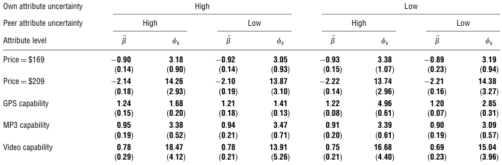

NOTE: complex table shown as an image of the PDF; the text below is a rough machine extraction and may be mis-aligned.

**extracted text (unreliable layout)**

Note. Parameter estimates whose 95% credible interval does not contain zero are in bold; base price is $129.

We developed seven alternate data sets for measuring preference revisions because of peer influence. Data set 1 employed the self-reported sociometric data about the extent to which each peer influences the choice decisions of the focal consumer. In data set 2, self-reported influencer data were replaced with data on social network membership such that *wii*′ = 1 if respondent *i*<sup>′</sup> was a member of at least one online social network of consumer *i*. Data set 3 used data about the frequency of interaction between the two respondents (*wii*′ = 1 if respondent *i* interacts at least once a week with respondent *i*<sup>′</sup>), whereas data set 4 used demographic data to populate the sociomatrix. Therefore *wii*′ = 1 if respondent *i* and *i*<sup>′</sup> were of the same age group (20–24, 25–34, and 35–44 years) or of the same gender. Data sets 5 and 6 were based on the similarity of age and gender, respectively.

Self-reported sociometric data about the extent of peer influence led to the best model performance in terms of in- and out-of-sample predictive ability (Table 7). Social network membership data were next, followed by data on frequency of interaction in terms of predictive availability. These three data sets induced better model performance than sociometric data based on similarity of demographic characteristics (data sets 4–6). In the absence of self-reported influencer data, researchers interested in inferring peer influencing therefore might do well to replace demographic data with data about online social network membership or frequency of interactions. Data from online social networks might be less expensive and time consuming to collect than survey data, as well as offer the promise of greater response rates. The relative performance of interaction frequency compared with demographic similarity data also supports the industry practice (Godes and Mayzlin 2009) in viral marketing of using such data to measure the performance of agents who interact with consumers with

the intention of influencing their choices. Finally, when we evaluated model performance with the assumption that all respondents influenced all other respondents (i.e., *wii*′ = 1 if *i*̸ = *i*<sup>′</sup>, and 0 otherwise; see data set 7), we found worse predictive performance, despite the attractive benefits of not requiring the collection of any sociometric or demographic data.

**6. Contribution, Managerial Implications, and Further Research** Early research on peer influence (e.g., Bearden and Etzel 1982, Childers and Rao 1992) focused on social influence variation with product characteristics; more recent research has studied such influence in various contexts (e.g., Argo et al. 2008, Berger and Heath 2007, Manchanda et al. 2008, McFerran et al. 2010, Nair et al. 2010). We study the effect of social influence on product choice at the product attribute level instead

**Table 7 In-Sample and Out-of-Sample Predictive Performance (Study 1)**

|  |  | Predictive |  | fitstatistics |
| --- | --- | --- | --- | --- |
|  | Basisof | Insample |  | Outofsample |
| Dataset | preferencerevision | Hitrate | MSE | Hitrate MSE |
| 1 2 | Choicesofinfluencers Choicesofsocial | 0910 0870 | 0025 0029 | 0639 0074 0635 0077 |
| 3 | networkmembers Choicesofsubjectswith | 0870 | 0031 | 0635 0080 |
| 4 | positivefrequency ofinteraction Choicesofsubjectsof | 0820 | 0034 | 0612 0081 |
| 5 | sameagegroupor samegender Choicesofsubjectsof | 0788 | 0041 | 0596 0087 |
| 6 | sameagegroup Choicesofsubjects | 0753 | 0047 | 0590 0087 |
| 7 | ofsamegender Choicesofallothersubjects | 0739 | 0049 | 0575 0097 |

NOTE: table converted from PDF layout to HTML text; cell boundaries are reconstructed. See PDF if exact alignment matters.

of the product level. Moreover, by comparing several theoretical mechanisms underlying peer influence, we extend this literature to a multiattribute judgment domain. Models that do not account for revisions in attribute preferences perform worse in terms of fit and predictive ability, which underscores the importance of studying social influence at a disaggregated level. To the best of our knowledge, our study is also the first application of a Bayesian updating approach to model changes in consumers’ attribute preferences in the context of multiattribute judgments under peer influence. Another novel aspect of this research is studying the role of attribute preference uncertainty of consumers and their peers, in peer influence. More generally, we shed light on the process of how consumers integrate product-related information with information on others’ choices to make choice decisions.

Third, peer influence appears to induce greater preference revision when the peers’ attribute preferences are relatively certain. Word of mouth about a product thus should have a greater effect when it communicates great certainty about attribute preferences.

Fourth, marketing researchers who want to estimate the extent of peer influence on their consumers but who lack access to detailed sociometric data can

employ easily accessed data about consumers’ online social network membership or the frequency of their interactions with peers as useful proxies.

Fifth, we have proposed an experimental approach to estimate the dependence of consumers’ WTP for specific attributes on peer influence. Practitioners might adopt this approach to support pricing decisions for products for which choices are influenced by peers.

This research is not without limitations. Our twostage experimental design is quite representative of real-world decision making situations wherein consumers have decided to buy a product, are unsure of which specific item to purchase, and obtain information about peers’ real or stated choices. The availability of such information is facilitated by frequent offline interactions in the real world as well as with the increased use of electronic communication media. Our study might be less representative of those forms of peer interactions, which do not involve sharing of choice-related information. For example, peers might share information related solely to their attributes preferences (e.g., “I would not buy any book reader other than Sony”). Furthermore, our results on peer influence can perhaps not be generalized to larger groups of peers (other students, friends, coworkers, etc.).

This research can be extended in several directions. We study consumer decisions of which alternative to chose among several alternatives. Our approach can be adapted to study the effect of peer influence on related consumer decisions such as whether to buy, when to buy, and how much to buy. Our approach is also applicable for studying the effect of coworker decisions on individual-level managerial decisions within organizations. Research on social learning suggests two distinct routes—observational learning and information sharing (Zhang 2010). The respondents in our approach observe the decisions made by their influencers but do not receive any other information from them. Thus a logical extension would be to develop an approach that incorporates both forms of social learning. The relative influence of different subgroups of consumers on individual consumer decisions remains an underexplored research area. Although the demands of data collection for attempting to solve such problems can be daunting, our results suggest that the use of online social network data for studying social influence might be worth exploring further.

**Acknowledgments** The authors thank Sachin Gupta and Young-Hoon Park for detailed feedback. They also thank seminar participants at the University of Chicago, Yale University, the National University of Singapore, and the Marketing Science Conference 2010 for several helpful comments.

**Appendix. The Markov Chain Monte Carlo Estimation Algorithm for Mechanism 1** The final model is specified by Equations (1)–(6) and (9). Estimation is carried out by sequentially generating draws from the following conditional distributions:

The second term in the parentheses accounts for the likelihood of the choice data for consumer *i* collected in the postinfluence stage.

The third term in the parentheses accounts for the likelihood of the choice data in the postinfluence stage for all consumers who consider consumer *i* to be their influencers. The final term accounts for the prior heterogeneity distribution specified by Equation (3).

#### **References**

Amaldoss, W., S. Jain. 2005. Pricing of conspicuous goods: A com-

petitive analysis of social effects. *J. Marketing Res.* **42**(1) 30–42. Argo, J. J., D. W. Dahl, A. C. Morales. 2008. Positive consumer

contagion: Responses to attractive others in a retail context. *J. Marketing Res.* **45**(6) 690–701.

Aribarg, A., N. Arora, M. Y. Kang. 2010. Predicting joint choice

using individual data. *Marketing Sci.* **29**(1) 139–157. Arora, N., G. M. Allenby. 1999. Measuring the influence of individ-

ual preference structures in group decision making. *J. Marketing Res.* **36**(4) 476–487. Bearden, W. O., M. J. Etzel. 1982. Reference group influence

on product and brand purchase decisions. *J. Consumer Res.* **9**(September) 183–194. Bell, D. R., S. Song. 2007. Neighborhood effects and trial on the

Internet: Evidence from online grocery retailing. *Quant. Marketing Econom.* **5**(4) 361–400. Berger, J., C. Heath. 2007. Where consumers diverge from others:

Identity signaling and product domains. *J. Consumer Res.* **34**(2) 121–134. Bradlow, E. T., Y. Hu, T.-H. Ho. 2004. A learning-based model for

imputing missing levels in partial conjoint profiles. *J. Marketing Res.* **41**(4) 369–381. Brewer, M. B. 1991. The social self: On being the same and different

at the same time. *Personality Soc. Psych. Bull.* **17**(5) 475–482. Calvó-Armengol, A., E. Patacchini, Y. Zenou. 2009. Peer effects

and social networks in education. *Rev. Econom. Stud.* **76**(4) 1239–1267. Childers, T. L., A. R. Rao. 1992. The influence of familial and peer-

based reference groups on consumer decisions. *J. Consumer Res.* **19**(2) 198–211. Corfman, K. P., D. R. Lehmann. 1987. Models of cooperative

group decision-making and relative influence: An experimental investigation of family purchase decisions. *J. Consumer Res.* **14**(1) 1–13. Costenbader, E., T. W. Valente. 2003. The stability of centrality mea-

sures when networks are sampled. *Soc. Networks* **25**(4) 283–307. DeGroot, M. H. 1970. *Optimal Statistical Decisions*. John Wiley &

Sons, New York. Edwards, Y. D., G. M. Allenby. 2003. Multivariate analysis of mul-

tiple response data. *J. Marketing Res.* **40**(3) 321–334. Erdem, T. 1996. A dynamic analysis of market structure based on

panel data. *Marketing Sci.* **15**(4) 359–378. Erdem, T., M. P. Keane. 1996. Decision-making under uncertainty:

Capturing dynamic brand choice processes in turbulent consumer goods markets. *Marketing Sci.* **15**(1) 1–20. Erdem, T., B. Sun. 2002. An empirical investigation of the spillover

effects of advertising and sales promotions in umbrella branding. *J. Marketing Res.* **39**(4) 408–420. Galaskiewicz, J. 1991. Estimating point centrality using different

network sampling techniques. *Soc. Networks* **13**(4) 347–386. Gilbride, T. J., G. M. Allenby. 2004. A choice model with conjunc-

tive, disjunctive, and compensatory screening rules. *Marketing Sci.* **23**(3) 391–406. Godes, D., D. Mayzlin. 2009. Firm-created word-of-mouth com-

munication: Evidence from a field test. *Marketing Sci.* **28**(4) 721–739. Green, P. E., A. M. Krieger. 1995. Attribute importance weights

modification in assessing a brand’s competitive potential. *Marketing Sci.* **14**(3, Part 1 of 2) 253–270. Hallinan, M. T., R. A. Williams. 1987. The stability of students’ inter-

racial friendships. *Amer. Sociol. Rev.* **52**(5) 653–664. Hartmann, W. R. 2010. Demand estimation with social interac-

tions and the implications for targeted marketing. *Marketing Sci.* **29**(4) 585–601. Hartmann, W. R., P. Manchanda, H. Nair, M. Bothner, P. Dodds,

D. Godes, K. Hosanagar, C. Tucker. 2008. Modeling social interactions: Identification, empirical methods and policy implications. *Marketing Lett.* **19**(3) 287–304. Iyengar, R., C. Van den Bulte, T. W. Valente. 2011. Opinion leader-

ship and social contagion in new product diffusion. *Marketing Sci.* **30**(2) 195–212.

Jacoby, J., J. J. Jaccard, I. Currim, A. Kuss, A. Ansari, T. Troutman.

1994. Tracing the impact of item-by-item information accessing on uncertainty reduction. *J. Consumer Res.* **21**(2) 291–303. Kahn, B. E., R. J. Meyer. 1991. Consumer multiattribute judg-

ments under attribute-weight uncertainty. *J. Consumer Res.* **17**(4) 508–522. Kahn, B. E., R. K. Sarin. 1988. Modeling ambiguity in decisions

under uncertainty. *J. Consumer Res.* **15**(2) 265–273. Karmarkar, U. R., Z. L. Tormala. 2010. Believe me, I have no idea

what I’m talking about: The effects of source certainty on consumer involvement and persuasion. *J. Consumer Res.* **36**(6) 1033–1049. Kratzer, J., C. Lettl. 2009. Distinctive roles of lead users and opinion

leaders in the social networks of schoolchildren. *J. Consumer Res.* **36**(December) 646–659. Lenk, P. 2009. Simulation pseudo-bias correction to the harmonic

mean estimator of integrated likelihoods. *J. Comput. Graphical Statist.* **18**(4) 941–960. Manchanda, P., Y. Xie, N. Youn. 2008. The role of targeted com-

munication and contagion in product adoption. *Marketing Sci.* **27**(6) 961–976. McFerran, B., D. W. Dahl, G. F. Fitzsimons, A. C. Morales. 2010.

I’ll have what she’s having: Effects of social influence and body type on the food choices of others. *J. Consumer Res.* **36**(6) 915–929. Meyer, R. J. 1981. A model of multiattribute judgments under

attribute uncertainty and informational constraint. *J. Marketing Res.* **18**(4) 428–441. Muthukrishnan, A. V., M. T. Pham, A. Mungale. 2001. Does greater

amount of information always bolster attitudinal resistance? *Marketing Lett.* **12**(2) 131–144. Nair, H. S., P. Manchanda, T. Bhatia. 2010. Asymmetric social inter-

actions in physician prescription behavior: The role of opinion leaders. *J. Marketing Res.* **47**(5) 883–895. Narayanan, S., P. Manchanda. 2009. Heterogeneous learning and

the targeting of marketing communication for new products. *Marketing Sci.* **28**(3) 424–441. Netzer, O., O. Toubia, E. T. Bradlow, E. Dahan, T. Evgeniou,

F. M. Feinberg, E. M. Feit et al. 2008. Beyond conjoint analysis: Advances in preference measurement. *Marketing Lett.* **19**(3–4) 337–354. Newton, M. A., A. E. Raftery. 1994. Approximate Bayesian inference

with the weighted likelihood bootstrap. *J. Roy. Statist. Soc. B* **56**(1) 3–48. Pornpitakpan, C. 2004. The persuasiveness of source credibility:

A critical review of five decades’ evidence. *J. Appl. Soc. Psych.* **34**(2) 243–281. Rao, V. R., J. H. Steckel. 1991. A polarization model for describing

group preferences. *J. Consumer Res.* **18**(1) 108–118. Rao, V. R., J. H. Steckel. 1995. Selecting, evaluating, and updat-

ing prospects in direct mail marketing. *J. Direct Marketing* **9**(2) 20–31. Roberts, J. H., G. L. Urban. 1988. Modeling multiattribute utility,

risk, and belief dynamics for new consumer durable brand choice. *Management Sci.* **34**(2) 167–185. Sacerdote, B. 2001. Peer effects with random assignment: Results

for Dartmouth roommates. *Quart. J. Econom.* **116**(2) 681–704. Salisbury, L. C., F. M. Feinberg. 2010. Alleviating the constant

stochastic variance assumption in decision research: Theory, measurement, and experimental test. *Marketing Sci.* **29**(1) 1–17. Shocker, A. D., V. Srinivasan. 1979. Multiattribute approaches for

product concept evaluation and generation: A critical review. *J. Marketing Res.* **16**(2) 159–180. Sniezek, J. A., L. M. Van Swol. 2001. Trust, confidence, and exper-

tise in a judge-advisor system. *Organ. Behav. Human Decision Processes* **84**(2) 288–307.

Sonnier, P. G., A. Ainslie, T. Otter. 2007. Heterogeneity distribu-

tions of willingness-to-pay in choice models. *Quant. Marketing Econom.* **5**(3) 313–331. Tormala, Z. L., R. E. Petty. 2002. What doesn’t kill me makes me

stronger: The effects of resisting persuasion on attitude certainty. *J. Personality Soc. Psych.* **83**(6) 1298–1313. Train, K. 2003. *Discrete Choice Methods with Simulation*. Cambridge

University Press, New York. Valente, T. W., B. R. Hoffman, A. Ritt-Olson, K. Lichtman,

C. A. Johnson. 2003. Effects of a social-network method for group assignment strategies on peer-led tobacco prevention programs in schools. *Amer. J. Public Health* **93**(11) 1837–1843. Van den Bulte, C. 2010. Opportunities and challenges in study-

ing customer networks. S. H. K. Wuyts, M. G. Dekimpe,

E. Gijsbrechts, F. G. M. Pieters, eds. *The Connected Customer: The Changing Nature of Consumer and Business Markets*. Routledge, London, 7–35. Van den Bulte, C., G. L. Lilien. 2001. *Medical Innovation* revisited:

Social contagion versus marketing effort. *Amer. J. Sociol.* **106**(5) 1409–1435. Yang, S., G. M. Allenby. 2003. Modeling interdependent consumer

preferences. *J. Marketing Res.* **40**(3) 282–294. Yang, S., V. Narayan, H. Assael. 2006. Estimating the interde-

pendence of television program viewership between spouses: A Bayesian simultaneous equation model. *Marketing Sci.* **25**(4) 336–349. Zhang, J. 2010. The sound of silence: Evidence of observational

learning in the U.S. kidney market. *Marketing Sci.* **29**(2) 315–335.